# PCA Exercises with Biological Dataset

# PCA Exercises with Biological Dataset (`airway`)

```r
# Install and load necessary packages
if (!requireNamespace("BiocManager", quietly = TRUE)) {
  install.packages("BiocManager")
}
if (!requireNamespace("airway", quietly = TRUE)) {
  BiocManager::install("airway")
}
if (!requireNamespace("AnnotationDbi", quietly = TRUE)) {
  BiocManager::install("AnnotationDbi")
}
if (!requireNamespace("org.Hs.eg.db", quietly = TRUE)) {
  BiocManager::install("org.Hs.eg.db")
}

library(ggplot2)
library(DESeq2)
library(airway)
library(AnnotationDbi)
library(org.Hs.eg.db)

# Load airway dataset
data(airway)
```

## Exercise 1: Perform PCA on RNA-seq Data

- **Objective**: Perform PCA on the normalized counts of the **airway** dataset after variance stabilization.

```r
dds <- DESeqDataSet(airway, design=~dex)

# Perform variance stabilizing transformation (VST)
vsd <- vst(dds, blind = FALSE)

# Extract the top 500 most variable genes for PCA
top_var_genes <- order(rowVars(assay(vsd)), decreasing = TRUE)[1:500]

# Perform PCA on the top 500 most variable genes
pca_result <- prcomp(t(assay(vsd)[top_var_genes, ]), center = TRUE, scale. = TRUE)

# Calculate proportion of variance explained by each component
var_explained <- pca_result$sdev^2 / sum(pca_result$sdev^2)

# Display summary of PCA result
summary(pca_result)
```

```
## Importance of components:
##                           PC1     PC2    PC3     PC4     PC5     PC6     PC7
## Standard deviation     15.198 11.0602 8.8165 7.05108 3.14998 2.44650 1.82629
## Proportion of Variance  0.462  0.2447 0.1555 0.09944 0.01984 0.01197 0.00667
## Cumulative Proportion   0.462  0.7066 0.8621 0.96151 0.98136 0.99333 1.00000
##                              PC8
## Standard deviation     1.372e-14
## Proportion of Variance 0.000e+00
## Cumulative Proportion  1.000e+00
```

- **Your Task**: Create a **scree plot** using `ggplot2` to visualize the proportion of variance explained by each principal component.

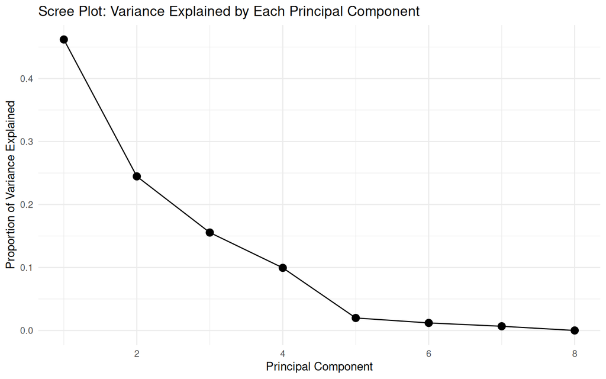

```r
# Solution to Exercise 1

# Create a dataframe for ggplot
var_explained_df <- data.frame(PC = 1:length(var_explained), Variance = var_explained)

# Create scree plot using ggplot2
ggplot(var_explained_df, aes(x = PC, y = Variance)) +
  geom_point(size = 3) +
  geom_line(group = 1) +
  ggtitle("Scree Plot: Variance Explained by Each Principal Component") +
  xlab("Principal Component") +
  ylab("Proportion of Variance Explained") +
  theme_minimal()
```

## Exercise 2: PCA Scatter Plot of the First Two Principal Components

- **Objective**: Visualize the first two principal components using a **scatter plot** with `ggplot2`.

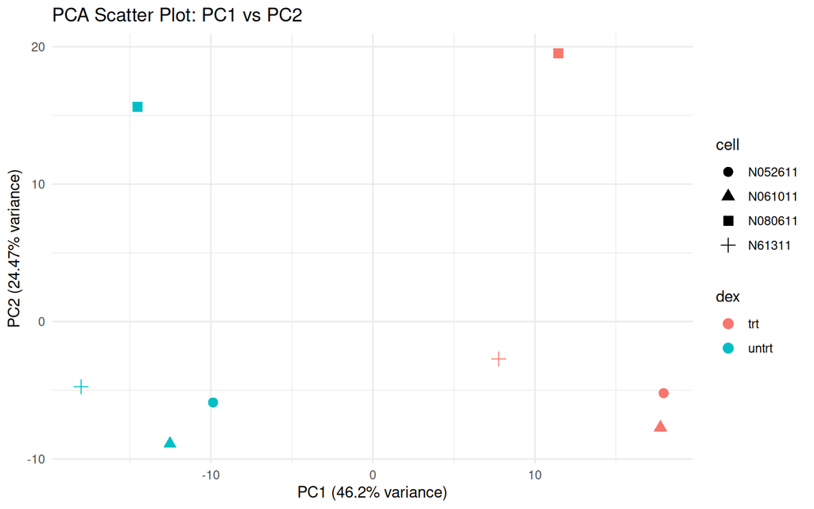

```r
# Get the PCA scores (coordinates for each sample on the principal components)
pca_scores <- as.data.frame(pca_result$x)

# Add sample metadata (cell type and dex treatment) to the PCA scores
pca_scores$cell <- colData(vsd)$cell
pca_scores$dex <- colData(vsd)$dex

# Create scatter plot for PC1 and PC2
ggplot(pca_scores, aes(x = PC1, y = PC2, color = dex, shape = cell)) +
  geom_point(size = 3) +
  ggtitle("PCA Scatter Plot: PC1 vs PC2") +
  xlab(paste0("PC1 (", round(var_explained[1] * 100, 2), "% variance)")) +
  ylab(paste0("PC2 (", round(var_explained[2] * 100, 2), "% variance)")) +
  theme_minimal()
```

- **Your Task**:
1. Look at the PCA scatter plot of PC1 vs. PC2 from **Exercise 2**.
2. Answer the following questions:
   - Are the samples from the dexamethasone-treated group separated from the untreated group?
   - Which principal component (PC1 or PC2) seems to capture more of the variation between the treatment groups?
   - What might the separation along PC1 or PC2 indicate about the influence of dexamethasone on gene expression in this dataset?

```r
# Solution to Exercise 2.1

# The PCA scatter plot shows that the samples treated with dexamethasone are clearly separated
# from the untreated samples along the first principal component (PC1). This indicates that
# dexamethasone treatment is the main source of variation in the gene expression data.

# PC1 explains a larger proportion of the variance (as indicated in the labels), suggesting that
# most of the gene expression changes due to treatment are captured by this component. The separation
# along PC1 suggests that the dexamethasone treatment has a significant impact on the overall gene expression profile.
```

## Exercise 3: Visualizing the Top 20 Loadings on the First Two Principal Components

- **Objective**: Create a **loading plot** for the top 20 genes using `ggplot2` and annotate the Ensembl IDs with gene symbols.

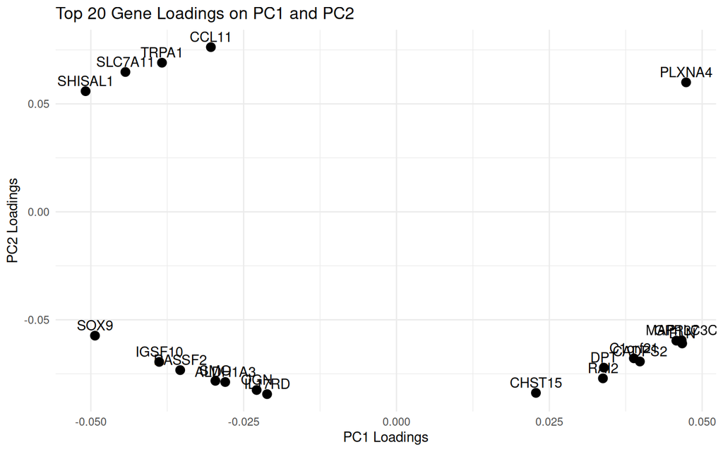

```r
# Extract loadings for the first two components
pca_loadings <- as.data.frame(pca_result$rotation[, 1:2])

# Get the top 20 genes with the highest absolute loadings in PC1 and PC2
top_genes <- head(order(abs(pca_loadings$PC1) + abs(pca_loadings$PC2), decreasing = TRUE), 20)

# Subset the PCA loadings to the top 20 genes
top_loadings <- pca_loadings[top_genes, ]

# Annotate gene symbols from Ensembl IDs
top_loadings$ensembl_id <- rownames(top_loadings)
top_loadings$gene_symbol <- mapIds(org.Hs.eg.db, keys = top_loadings$ensembl_id,
                                   column = "SYMBOL", keytype = "ENSEMBL", multiVals = "first")
# Remove genes with missing symbols and create a loading plot
top_loadings <- na.omit(top_loadings)

# Create loading plot using ggplot2
ggplot(top_loadings, aes(x = PC1, y = PC2, label = gene_symbol)) +
  geom_point(size = 3) +
  geom_text(vjust = -0.5, hjust = 0.5) +
  ggtitle("Top 20 Gene Loadings on PC1 and PC2") +
  xlab("PC1 Loadings") +
  ylab("PC2 Loadings") +
  theme_minimal()
```

- **Your Task**: Identify the top 20 genes contributing to PC1 and PC2, and explain their potential biological significance.

```r
# Solution to Exercise 3

# Interpretation of top 20 loadings:
# The top 20 genes with the highest loadings on PC1 and PC2 are the most important
# for explaining the variance captured by these components. These genes could be involved
# in biological processes related to dexamethasone treatment or the cell types used in the study.
```